# STT 5811 Take Home

Brianna Bentley

Last compiled: Apr 25, 2018

Follow all directions. Type complete sentences to answer all questions inside the `answer` tags provided in the R Markdown document. Round all numeric answers you report inside the answer tags to four decimal places. Use inline `R` code to report numeric answers inside the `answer` tags (i.e. do not hard code your numeric answers). You may discuss general concepts with your classmates; however, you should not discuss individual questions from the take home with anyone other than faculty. You may use books, notes, and the internet to help you answer the questions. Replace the *Your Name* in the YAML with your name (First, Last).

1. Load the package `hflights` and read about the data set. Display the first 10 rows and 7 columns of `hflights` using the `datatable` function from the `DT` package.

```r
library(hflights)
library(DT)
hflights2.0 <- hflights %>%
  select(Year, Month, DayofMonth, DayOfWeek, DepTime, ArrTime, UniqueCarrier)
datatable(head(hflights2.0, 10))
```

|  | Year | Month | DayofMonth | DayOfWeek | DepTime | ArrTime | UniqueCarrier |
| --- | --- | --- | --- | --- | --- | --- | --- |
| 5424 | 2011 | 1 | 1 | 6 | 1400 | 1500 | AA |
| 5425 | 2011 | 1 | 2 | 7 | 1401 | 1501 | AA |
| 5426 | 2011 | 1 | 3 | 1 | 1352 | 1502 | AA |
| 5427 | 2011 | 1 | 4 | 2 | 1403 | 1513 | AA |
| 5428 | 2011 | 1 | 5 | 3 | 1405 | 1507 | AA |
| 5429 | 2011 | 1 | 6 | 4 | 1359 | 1503 | AA |
| 5430 | 2011 | 1 | 7 | 5 | 1359 | 1509 | AA |
| 5431 | 2011 | 1 | 8 | 6 | 1355 | 1454 | AA |
| 5432 | 2011 | 1 | 9 | 7 | 1443 | 1554 | AA |
| 5433 | 2011 | 1 | 10 | 1 | 1443 | 1553 | AA |

2. What are the dimensions of the `hflights` data frame?

```r
dimensions <- dim(hflights)
```

The dimensions of the `hflights` data frame are 227496, 21.

3. How many weekend flights flew a distance of more than 1300 miles and had a total taxiing time (`TaxiIn` + `TaxiOut`) below 10 minutes?

```r
library(dplyr)
WKND <- hflights %>%
  filter(DayOfWeek == c(6,7) & Distance > 1300 & TaxiIn + TaxiOut < 10)
number <- nrow(WKND)
```

21 weekednd flights flew a distance of more than 1300 miles and had a total taxiing time below 10 minutes.

4. Create a new data frame Q4B that satisfies the following conditions: a) Only the carriers `CO` and `XE` are included in the variable `UniqueCarrier`; b) The levels of `UniqueCarrier` are labelled `Continental` and `Express Jet`; c) A new variable `TotalDelay` is created with `mutate` that is the sum of the arrival and departure delays; d) Only the flights on Saturday that are between 650 and 720 miles in distance are included (use `filter`). Once your data frame is created, report its dimensions.

```r
Q4B <- hflights %>%
  filter(UniqueCarrier == c("CO", "XE")) %>%
  mutate(TotalDelay = ArrDelay + DepDelay) %>%
  filter(DayOfWeek == "6" & Distance > 650 & Distance < 720) #%>%
  #rename(Q4B$UniqueCarrier, c("CO" = "Continental", "XE" = "Express Jet"))
dimensionss <- dim(Q4B)
```

The dimensions of the new Q4B data frame is 342, 22.

5. Use the information in `Q4B` to create a density histogram of the total delay time for the carriers `Continental` and `Express Jet`. Make the range of the $x$-axis -50 to 300 (minutes) for both density histograms. Superimpose a density curve over each histogram. Label the $x$-axis `Total Delay (minutes)`. Use the `fig.cap` option in your code chunk to create a descriptive caption. Based on the density histograms and appropriate summary measures, characterize the distribution of total delay time for both airlines. Make sure to reference the appropriate Figure using `\@ref(fig:yourlabelname)` when writing your answer. See [bookdown: Authoring Books and Technical Documents with R Markdown](https://bookdown.org/yihui/bookdown/) if you need a refresher on using cross-references.

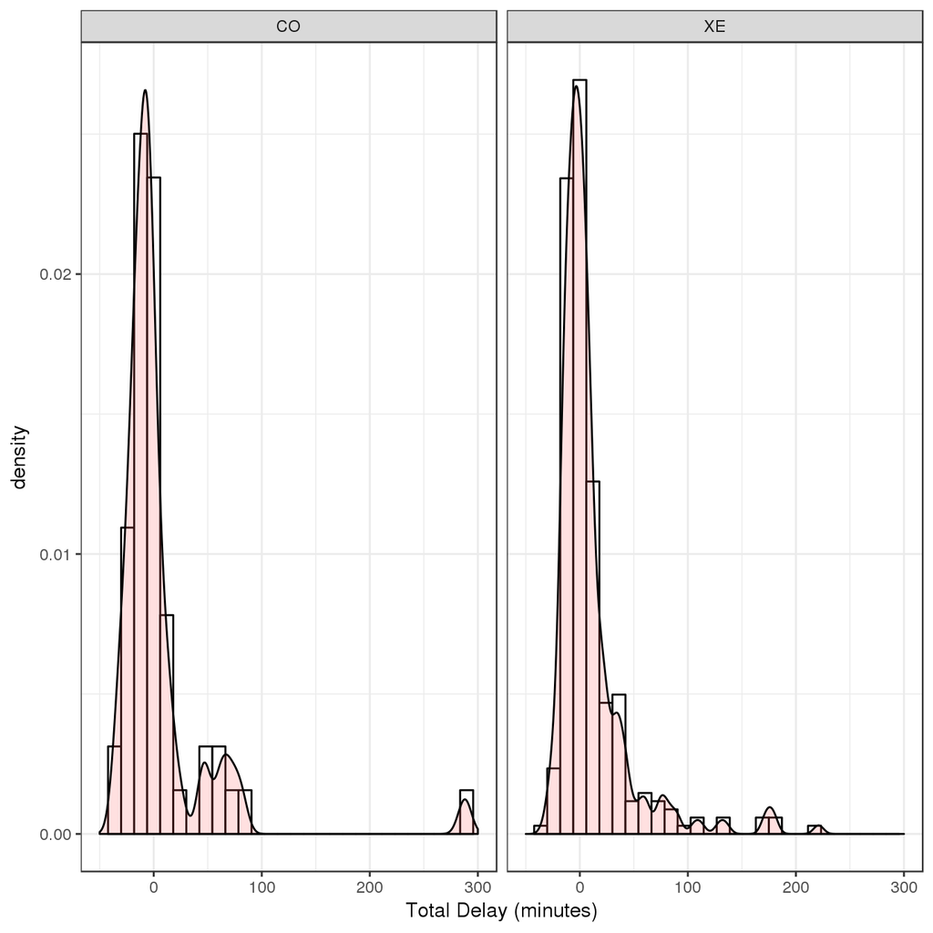

Figure 1: Airlines can’t be trusted!!!

```r
library(ggplot2)
ggplot(data = Q4B, aes(x = TotalDelay)) +
  geom_histogram(aes(y=..density..), colour="black", fill="white") +
  geom_density(alpha=.2, fill="#FF6666") +
  facet_grid(.~UniqueCarrier) +
  theme_bw() +
  xlim(-50, 300)+
  xlab("Total Delay (minutes)")
```

```r
CONT <- subset(Q4B, UniqueCarrier == "CO")
EXPRESS <- subset(Q4B, UniqueCarrier == "XE")
summary(CONT$TotalDelay)
```

```
   Min. 1st Qu.  Median    Mean 3rd Qu.    Max.
-34.000 -16.000  -6.000   4.981   4.000 288.000
```

```r
dim(CONT)
```

```
[1] 53 22
```

```r
summary(EXPRESS$TotalDelay)
```

```
   Min. 1st Qu.  Median    Mean 3rd Qu.    Max.    NA's
 -32.00   -8.00    1.00   14.26   13.00  756.00       4
```

```r
dim(EXPRESS)
```

```
[1] 289  22
```

6. Write out the hypotheses (in English and using appropriate statistical notation) to test if the median total delay time for Express Jet is greater than the median total delay time for Continental.

- Null Hypothesis: The median total delay time for Express Jet is equal to the median total delay time for Continental.
  - $H_0:$ $\mu_e = \mu_c$
- Alternative Hypothesis: The median total delay time for Express Jet is greater than the median total delay time for Continental.
  - $H_A:$ $\mu_e > \mu_c$
7. Test your hypotheses from Question 6 using a randomization approach.

```r
#Filter out NA values from the above subsets.
CONT2.0 <- CONT %>%
  filter(!is.na(TotalDelay))
EXP2.0 <- EXPRESS %>%
  filter(!is.na(TotalDelay))
```

```r
B <- 10^4 - 1
theta.hatE <- numeric(B)
set.seed(1)
for (i in 1:B) {
  index <- sample(length(CONT), length(CONT)/2, replace = FALSE)
  theta.hatE[i] <- median(CONT2.0$TotalDelay[index]) - median(EXP2.0$TotalDelay[-index])
}

PVALUE <- (sum(theta.hatE >= 7)+1)/(B+1)
PVALUE
```

```
[1] 0.0333
```

So we reject the null in favor of the alternative.

8. Construct and interpret a 90% bootstrap percentile confidence interval for the average `AirTime` for Continental minus the average `AirTime` for Express Jet. Create a density plot of the bootstrapped statistic. Make sure to reference the appropriate Figure using `\@ref(fig:yourlabelname)` when writing your answer.

Can’t get this to work!

```r
cont <- length(CONT)
express <- length(EXPRESS)
N <- 10000
cont.resamp <- numeric(N)
express.resamp <- numeric(N)

for (i in 1:N) {
  s.resample <- sample(CONT, cont, replace = TRUE)
  cont.resamp[i] <- mean(s.resample)
  ns.resample <- sample(EXPRESS, express, replace = TRUE)
  express.resamp[i] <- mean(ns.resample)
}

diffmeans <- cont.resamp - express.resamp
#quantile(diffmeans, probs = 0.90)
```

**Extra Credit:** Shade the middle 90% of the density histogram of the bootstrapped statistic purple and label the $x-$ axis $\bar{x}^*_{\text{Continental}} -\bar{x}^*_{\text{ExpressJet}}$.

```r
R <- 1000
TS <- numeric(R)

CI <- quantile(TS, probs = .90)
CI
```

[output not shown]

```
90%
  0
```

```r
#from arnholt's notes
#p <- ggplot(data = DF, aes(x = x, y = ..density..)) +
  #geom_density(fill = "red", alpha = 0.8) +
  #theme_bw()
#x.dens <- density(TS)
#df.dens <- data.frame(x = x.dens$x, y = x.dens$y)
#p + geom_area(data = subset(df.dens, x >= CI[1] & x <= CI[2]), aes(x = x, y = y), fill = "blue", alpha = .3)
```